# Project_1_Data_Story

## STAT 5243 Project 1 - Data Story

Author: Wenchang Zhu

Email: wz2632@columbia.edu

Project 1: **A "Data Story" on History of Philosophy**

**Summary**: This dataset was compiled for the Philosophy Data Project and used to develop the features available on that site. The initial goal was to build a classification model with the data. The dataset contains over 300,000 sentences from 59 texts spanning 13 major schools of philosophy. The represented schools are: Analytic Philosophy, Aristotle, Capitalism, Communism, Continental Philosophy, Empiricism, Feminism, German Idealism, Nietzsche, Phenomenology, Plato, Rationalism, and Stoicism.

This data story revolves around **four** questions:

1. What's the most popular school among these works?
2. Which school is more concise in expression?
3. What's the development history of the philosophy schools?
4. What's the key concept of each school?

```python
from google.colab import drive
drive.mount('/content/drive')
```

```python
# Read the philosophy dataset from https://www.kaggle.com/datasets/kouroshalizadeh/history-of-philosophy
# Read the more completed stopwords list from https://www.kaggle.com/datasets/rowhitswami/stopwords

import pandas as pd

data = pd.read_csv('drive/MyDrive/STAT_5243/philosophy_data.csv')
p_df = pd.DataFrame(data)

stop_words = []
with open('drive/MyDrive/STAT_5243/stopwords.txt', encoding='utf8') as f:
    for line in f:
      line=line.strip('\n')
      stop_words.append(line)
```

### Question 1: What's the most popular school among all these works?

```
school
analytic           11
aristotle           1
capitalism          3
communism           3
continental         6
empiricism          6
feminism            3
german_idealism     7
nietzsche           5
phenomenology       5
plato               1
rationalism         6
stoicism            2
Name: title, dtype: int64
```

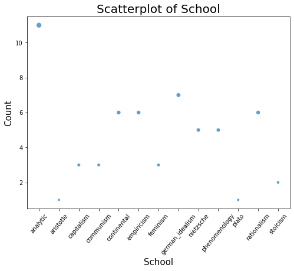

```python
import pandas as pd
import matplotlib.pyplot as plt
import seaborn as sns

school_count = p_df.groupby(['school'])['title'].nunique()   # Groupby school, focusing on each book
print(school_count)

pop_df = pd.DataFrame(school_count)
plt.figure(figsize = (8, 6))
sns.scatterplot(x='school', y='title', size='title', data=pop_df, legend=None, alpha=0.7)
plt.title('Scatterplot of School', fontsize=20)
plt.xticks(fontsize=10, rotation=50)
plt.xlabel('School', fontsize=15)
plt.ylabel('Count', fontsize=15)
```

### Question 2: Which school is more concise in expression?

Firstly, measure the concise degree by author.

```python
import pandas as pd

concise_df = pd.DataFrame()

sentence_count = p_df.groupby(['school'])['author'].value_counts()           # Count how many sentences an author wrote
author_count = p_df.groupby(['school', 'author'])['sentence_length'].sum()   # Count the total word count an author wrote

# create a dataframe to store the data
concise_df['sentence_count'] = pd.DataFrame(sentence_count)
concise_df['word_count'] = pd.DataFrame(author_count)
concise_df['word_per_sentence'] = concise_df['word_count']/concise_df['sentence_count']   # Calculate the word count per sentence for each author

concise_copy = concise_df.copy()
concise_copy.sort_values('word_per_sentence').head(5)   # Sort by 'word_per_sentence' ascendingly
```

| school | author | sentence_count | word_count | word_per_sentence |
| --- | --- | --- | --- | --- |
| analytic | Wittgenstein | 9034 | 766840 | 84.883772 |
|  | Lewis | 13120 | 1439495 | 109.717607 |
| plato | Plato | 38366 | 4409712 | 114.938018 |
| nietzsche | Nietzsche | 13548 | 1579695 | 116.599867 |
| stoicism | Epictetus | 323 | 38253 | 118.430341 |

Secondly, measure the concise degree by school.

```python
s_concise_df = pd.DataFrame()

s_sentence_count = p_df.groupby(['school'])['sentence_lowered'].count()   # Count how many sentences a school has
s_word_count = p_df.groupby(['school'])['sentence_length'].sum()          # Count how many words a school has

s_concise_df['sentence_count'] = pd.DataFrame(s_sentence_count)
s_concise_df['word_count'] = pd.DataFrame(s_word_count)
s_concise_df['word_per_sentence'] = s_concise_df['word_count']/s_concise_df['sentence_count']   # Calculate the word count per sentence for each school
s_concise_copy = s_concise_df.copy()
s_concise_copy.sort_values('word_per_sentence')   # Sort by 'word_per_sentence' ascendingly
```

| school | sentence_count | word_count | word_per_sentence |
| --- | --- | --- | --- |
| plato | 38366 | 4409712 | 114.938018 |
| nietzsche | 13548 | 1579695 | 116.599867 |
| analytic | 55425 | 6596972 | 119.025205 |
| stoicism | 2535 | 347438 | 137.056410 |
| phenomenology | 28573 | 4169182 | 145.913345 |
| communism | 17958 | 2743126 | 152.752311 |
| feminism | 18635 | 2852719 | 153.083928 |
| aristotle | 48779 | 7474160 | 153.224953 |
| rationalism | 22949 | 3762695 | 163.958996 |
| continental | 33779 | 5802964 | 171.792060 |
| german_idealism | 42136 | 7595070 | 180.251329 |
| empiricism | 19931 | 3660090 | 183.638051 |
| capitalism | 18194 | 3412763 | 187.576289 |

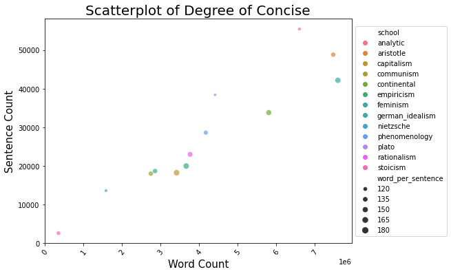

```python
import pandas as pd
import matplotlib.pyplot as plt
import seaborn as sns

# Use a scatterplot to show the relationship between word count and setence count for each school
plt.figure(figsize = (8, 6))
fig = sns.scatterplot(x='word_count', y='sentence_count', hue='school', size='word_per_sentence', data=s_concise_df, alpha=0.7)
fig.legend(loc='center left', bbox_to_anchor=(1, 0.5))
plt.title('Scatterplot of Degree of Concise', fontsize=20)
plt.xticks(fontsize=10, rotation=50)
plt.xlabel('Word Count', fontsize=15)
plt.ylabel('Sentence Count', fontsize=15)
```

### Question 3: What‘s the chronology of the emergence of these philosophy schools?

```python
import numpy as np
import pandas as pd

# Find the earliest publication date for each school
year_df = p_df.copy()
year_df = year_df[['school', 'original_publication_date']]
year_df.sort_values(['original_publication_date'], ascending=1, inplace=True)
grouped = year_df.groupby(['school']).head(1)

# Print the chronology of the emergence
print(grouped)
grouped_list = list(grouped['school'])
print('The chronology of the emergence of these philosophy schools is ' + ', '.join(map(str, grouped_list)) + '.')
```

```
                 school  original_publication_date
0                 plato                       -350
70884         aristotle                       -320
326310         stoicism                        125
116216      rationalism                       1637
88025        empiricism                       1689
315453       capitalism                       1776
261902  german_idealism                       1781
343988         feminism                       1792
303357        communism                       1848
330426        nietzsche                       1886
232393    phenomenology                       1907
136114         analytic                       1910
191588      continental                       1961
The chronology of the emergence of these philosophy schools is plato, aristotle, stoicism, rationalism, empiricism, capitalism, german_idealism, feminism, communism, nietzsche, phenomenology, analytic, continental.
```

### Question 4: What's the most popular word for each school?

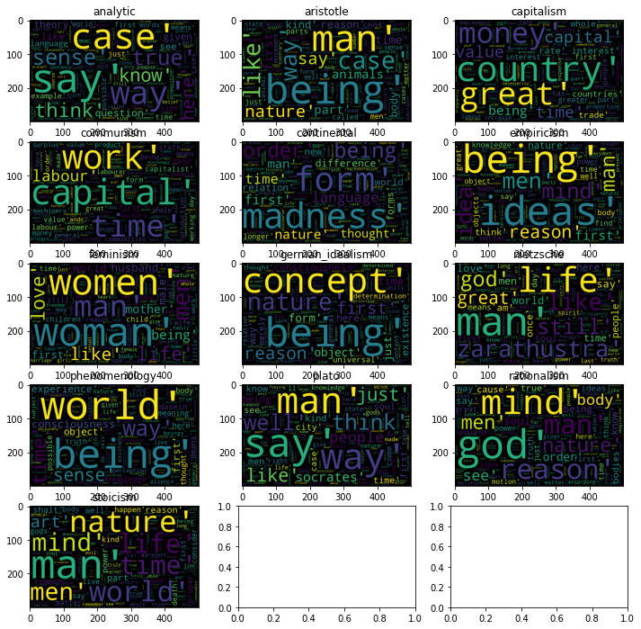

```python
import numpy as np
import pandas as pd
import string
import matplotlib.pyplot as plt
%matplotlib inline
from wordcloud import WordCloud

# Combine the tokenized_txt of each group
# Remove stopwords from tokenized_txt
school_df = p_df[['school', 'tokenized_txt']]
for index, row in school_df.iterrows():
  tmp = row['tokenized_txt'][1:-1].split(',')
  tmp = [word.translate(str.maketrans(string.punctuation, " "*len(string.punctuation))).strip() for word in tmp]
  tmp = [word for word in tmp if word not in stop_words]
  row['tokenized_txt'] = tmp

# Creat word cloud for each school and highlight its most frequent word
school_df = school_df.groupby(['school'])['tokenized_txt'].apply(lambda x: [*x]).reset_index()
f, axarr = plt.subplots(5,3, figsize=(12, 12))   # Subplot(r,c) provide the no. of rows and columns
for index, row in school_df.iterrows():
  word_Cloud = WordCloud(width=500, height=300, random_state=21, max_font_size=119).generate(str(row['tokenized_txt']))
  title = row['school']
  axarr[index // 3, index % 3].imshow(word_Cloud)
  axarr[index // 3, index % 3].title.set_text(title)
```

## For the Question:

1. The most popular school among works is Analytic, 11 out of 59.
2. Four relatively concise schools are Plato, Nietzsche, Analytic, and Stoicism.
3. The chronology of the emergence of these philosophy schools is Plato, Aristotle, Stoicism, Rationalism, Empiricism, Capitalism, German Idealism, Feminism, Communism, Nietzsche, Phenomenology, Analytic, Continental.
4. For this question, we creates a word cloud for each school.

**Limitations:**

1. The dataset is relatively small, so we may lack powerful proof for the questions.
2. We have no idea how the sentences were selected and whether those sentences were typical or classical for the philosopher/school, so the word clouds of each school may be biased.